# abalone_benchmarks 数据集分析

## 我们使用PyOD工具包来完成本次的离群点分析任务，首先导入所有需要的函数库

```python
from __future__ import division
from __future__ import print_function

import os
import sys
from time import time
import numpy as np
from numpy import percentile
import pandas as pd

from scipy.io import loadmat

import warnings

warnings.filterwarnings("ignore")

from pyod.models.abod import ABOD
from pyod.models.cblof import CBLOF
from pyod.models.feature_bagging import FeatureBagging
from pyod.models.hbos import HBOS
from pyod.models.iforest import IForest
from pyod.models.knn import KNN
from pyod.models.lof import LOF
from pyod.models.mcd import MCD
from pyod.models.ocsvm import OCSVM
from pyod.models.pca import PCA

from pyod.utils.example import visualize
from pyod.utils.utility import standardizer
from pyod.utils.utility import precision_n_scores

from sklearn.metrics import roc_auc_score
from sklearn.model_selection import train_test_split
from sklearn.manifold import TSNE
from sklearn.decomposition import PCA as PCA_d
```

## 1、认识数据集

### 压缩包里的benchmarks文件夹里包含许多csv文件，每个benchmark对应每个因子的一个级别。 对于mother set，我们遍历问题维度级别的所有组合，并构建具有这些设置的5个benchmarks。某些mother set的局限性意味着，对于每个所需设置，我们可能无法获得5个数据集。

### 首先看一下整体的数据情况

```python
df = pd.read_csv('/home/ubuntu/lh/liuhao/data/abalone/meta_data/abalone.preproc.csv')
df.info()
df.head()
```

```
<class 'pandas.core.frame.DataFrame'>
RangeIndex: 4177 entries, 0 to 4176
Data columns (total 12 columns):
 #   Column          Non-Null Count  Dtype
---  ------          --------------  -----
 0   point.id        4177 non-null   object
 1   motherset       4177 non-null   object
 2   origin          4177 non-null   object
 3   original.label  4177 non-null   int64
 4   ground.truth    4177 non-null   object
 5   V1              4177 non-null   float64
 6   V2              4177 non-null   float64
 7   V3              4177 non-null   float64
 8   V4              4177 non-null   float64
 9   V5              4177 non-null   float64
 10  V6              4177 non-null   float64
 11  V7              4177 non-null   float64
dtypes: float64(7), int64(1), object(4)
memory usage: 391.7+ KB
```

|  | point.id | motherset | origin | original.label | ground.truth | V1 | V2 | V3 | V4 | V5 | V6 | V7 |
| --- | --- | --- | --- | --- | --- | --- | --- | --- | --- | --- | --- | --- |
| 0 | abalone_point_0001 | abalone | regression | 15 | anomaly | -0.574489 | -0.432097 | -1.064297 | -0.641821 | -0.607613 | -0.726125 | -0.638140 |
| 1 | abalone_point_0002 | abalone | regression | 7 | nominal | -1.448812 | -1.439757 | -1.183837 | -1.230130 | -1.170770 | -1.205077 | -1.212842 |
| 2 | abalone_point_0003 | abalone | regression | 9 | nominal | 0.050027 | 0.122116 | -0.107978 | -0.309432 | -0.463444 | -0.356647 | -0.207114 |
| 3 | abalone_point_0004 | abalone | regression | 10 | anomaly | -0.699393 | -0.432097 | -0.347058 | -0.637743 | -0.648160 | -0.607527 | -0.602222 |
| 4 | abalone_point_0005 | abalone | regression | 7 | nominal | -1.615350 | -1.540523 | -1.422916 | -1.271933 | -1.215822 | -1.287183 | -1.320599 |

### 看一下benchmarks文件夹下所有文件的基本信息。

```python
dir_path = '/home/ubuntu/lh/liuhao/data/abalone/benchmarks'
file_list = os.listdir(dir_path)
file_list.sort()

all_column = np.zeros(len(file_list))
for i, name in enumerate(file_list):
    file = pd.read_csv(os.path.join(dir_path, name))
    shape = file.columns.values.shape[0]
    all_column[i] = shape

print(np.unique(all_column))
```

```
[13. 16. 21. 34.]
```

### 可见所有的文件根据特征数量可分为4类，打开文件可以发现，多出来的特征是额外添加的噪声。

## 2、离群点分析

### 之后，我们就要进行离群点分析的任务了。我们选择八种离群点检测算法，分别是:

1、异常值检测的线性模型： (1) PCA：主成分分析（使用到特征向量超平面的加权投影距离之和作为离群值得分） (2) MCD：最小协方差行列式（使用马哈拉诺比斯距离作为离群值） (3) OCSVM：一类支持向量机

2、基于接近度的异常值检测模型： (1) LOF：局部离群因子 (2) kNN：k最近邻（使用与第k个最近邻的距离作为离群值得分） (3) HBOS：基于直方图的离群值得分

3、离群集成和组合框架 (1) IForest：隔离森林 (2) FB：Feature Bagging

### 有一些benchmarks比较奇怪，比如说离群点比例大于50%，此时我们在处理过程中需要把ground truth中的正常点和离群点标签互换，否则初始化检测工具的时候会出错，注意这并不会影响最终结果，因为正常点和离群点都是相对的。还有一些benchmarks含有非常少的离群点，会导致测试集中不含有离群点，这时我们需要重新划分测试集。一些实现过程中的细节请看代码注释。

```python
# %%capture result

random_state = np.random.RandomState(42)

df_columns = ['Data', '#Samples', '# Dimensions', 'Outlier Perc',
              'FB', 'HBOS', 'IForest', 'KNN', 'LOF', 'MCD',
              'OCSVM', 'PCA']

roc_df = pd.DataFrame(columns=df_columns)
prn_df = pd.DataFrame(columns=df_columns)
time_df = pd.DataFrame(columns=df_columns)

for name in file_list:
    print("... Processing", name, '...')
    file = pd.read_csv(os.path.join(dir_path, name))

    X = file.values[:, 6:]
    y = (file.values[:, 5] == 'anomaly')+0
    outliers_fraction = np.count_nonzero(y) / len(y)
    outliers_percentage = round(outliers_fraction * 100, ndigits=4)


    if outliers_fraction > 0.5:
        outliers_fraction = 1 - outliers_fraction
        y = 1 - y

    # 保存结果
    roc_list = [name[:-4], X.shape[0], X.shape[1], outliers_percentage]
    prn_list = [name[:-4], X.shape[0], X.shape[1], outliers_percentage]
    time_list = [name[:-4], X.shape[0], X.shape[1], outliers_percentage]

    # 60% 训练集， 40% 测试集
    X_train, X_test, y_train, y_test = train_test_split(X, y, test_size=0.4,
                                                        random_state=random_state)
    # 当测试集只含有一类时重新划分
    while (len(np.unique(y_test)) != 2):
        X_train, X_test, y_train, y_test = train_test_split(X, y, test_size=0.4,
                                                            random_state=random_state)

    # 数据已经经过了标准化，直接传入就行
    X_train_norm, X_test_norm = X_train, X_test

    # 定义八种离群值检测工具进行比较
    classifiers = {
        'Feature Bagging': FeatureBagging(contamination=outliers_fraction,
                                          random_state=random_state),
        'Histogram-base Outlier Detection (HBOS)': HBOS(
            contamination=outliers_fraction),
        'Isolation Forest': IForest(contamination=outliers_fraction,
                                    random_state=random_state),
        'K Nearest Neighbors (KNN)': KNN(contamination=outliers_fraction),
        'Local Outlier Factor (LOF)': LOF(
            contamination=outliers_fraction),
        'Minimum Covariance Determinant (MCD)': MCD(
            contamination=outliers_fraction, random_state=random_state),
        'One-class SVM (OCSVM)': OCSVM(contamination=outliers_fraction),
        'Principal Component Analysis (PCA)': PCA(
            contamination=outliers_fraction, random_state=random_state),
    }

    for clf_name, clf in classifiers.items():
        t0 = time()
        clf.fit(X_train_norm)
        test_scores = clf.decision_function(X_test_norm)
        t1 = time()
        duration = round(t1 - t0, ndigits=4)
        time_list.append(duration)

        roc = round(roc_auc_score(y_test, test_scores), ndigits=4)
        prn = round(precision_n_scores(y_test, test_scores), ndigits=4)

#         print('{clf_name} ROC:{roc}, precision @ rank n:{prn}, '
#               'execution time: {duration}s'.format(
#             clf_name=clf_name, roc=roc, prn=prn, duration=duration))

        roc_list.append(roc)
        prn_list.append(prn)

    temp_df = pd.DataFrame(time_list).transpose()
    temp_df.columns = df_columns
    time_df = pd.concat([time_df, temp_df], axis=0)

    temp_df = pd.DataFrame(roc_list).transpose()
    temp_df.columns = df_columns
    roc_df = pd.concat([roc_df, temp_df], axis=0)

    temp_df = pd.DataFrame(prn_list).transpose()
    temp_df.columns = df_columns
    prn_df = pd.concat([prn_df, temp_df], axis=0)

print('Done!')
```

```
... Processing abalone_benchmark_0001.csv ...
... Processing abalone_benchmark_0002.csv ...
... Processing abalone_benchmark_0003.csv ...
... Processing abalone_benchmark_0004.csv ...
... Processing abalone_benchmark_0005.csv ...
... Processing abalone_benchmark_0006.csv ...
... Processing abalone_benchmark_0007.csv ...
... Processing abalone_benchmark_0008.csv ...
... Processing abalone_benchmark_0009.csv ...
... Processing abalone_benchmark_0010.csv ...
... Processing abalone_benchmark_0011.csv ...
... Processing abalone_benchmark_0012.csv ...
... Processing abalone_benchmark_0013.csv ...
... Processing abalone_benchmark_0014.csv ...
... Processing abalone_benchmark_0015.csv ...
... Processing abalone_benchmark_0016.csv ...
... Processing abalone_benchmark_0017.csv ...
... Processing abalone_benchmark_0018.csv ...
... Processing abalone_benchmark_0019.csv ...
... Processing abalone_benchmark_0020.csv ...
... Processing abalone_benchmark_0021.csv ...
... Processing abalone_benchmark_0022.csv ...
... Processing abalone_benchmark_0023.csv ...
... Processing abalone_benchmark_0024.csv ...
... Processing abalone_benchmark_0025.csv ...
... Processing abalone_benchmark_0026.csv ...
... Processing abalone_benchmark_0027.csv ...
... Processing abalone_benchmark_0028.csv ...
... Processing abalone_benchmark_0029.csv ...
... Processing abalone_benchmark_0030.csv ...
... Processing abalone_benchmark_0031.csv ...
... Processing abalone_benchmark_0032.csv ...
... Processing abalone_benchmark_0033.csv ...
... Processing abalone_benchmark_0034.csv ...
... Processing abalone_benchmark_0035.csv ...
... Processing abalone_benchmark_0036.csv ...
... Processing abalone_benchmark_0037.csv ...
... Processing abalone_benchmark_0038.csv ...
... Processing abalone_benchmark_0039.csv ...
... Processing abalone_benchmark_0040.csv ...
```

[output cut: 1671 more lines]

```
... Processing abalone_benchmark_1787.csv ...
... Processing abalone_benchmark_1788.csv ...
... Processing abalone_benchmark_1789.csv ...
... Processing abalone_benchmark_1790.csv ...
... Processing abalone_benchmark_1791.csv ...
... Processing abalone_benchmark_1792.csv ...
... Processing abalone_benchmark_1793.csv ...
... Processing abalone_benchmark_1794.csv ...
... Processing abalone_benchmark_1795.csv ...
... Processing abalone_benchmark_1796.csv ...
... Processing abalone_benchmark_1797.csv ...
... Processing abalone_benchmark_1798.csv ...
... Processing abalone_benchmark_1799.csv ...
... Processing abalone_benchmark_1800.csv ...
Done!
```

### 我们列出所有文件的处理时间

```python
print('Time complexity')
time_df.to_csv("abalone_time.csv")
time_df
```

```
Time complexity
```

|  | Data | #Samples | # Dimensions | Outlier Perc | FB | HBOS | IForest | KNN | LOF | MCD | OCSVM | PCA |
| --- | --- | --- | --- | --- | --- | --- | --- | --- | --- | --- | --- | --- |
| 0 | abalone_benchmark_0001 | 1888 | 7 | 48.3581 | 0.1515 | 2.191 | 0.339 | 0.0803 | 0.0187 | 0.6668 | 0.0727 | 0.0028 |
| 0 | abalone_benchmark_0002 | 1888 | 7 | 50.3708 | 0.1522 | 0.0036 | 0.3325 | 0.0774 | 0.0188 | 0.6446 | 0.0717 | 0.0028 |
| 0 | abalone_benchmark_0003 | 1888 | 7 | 52.4364 | 0.138 | 0.0031 | 0.3321 | 0.078 | 0.0183 | 0.6674 | 0.0745 | 0.003 |
| 0 | abalone_benchmark_0004 | 1888 | 7 | 47.1928 | 0.1502 | 0.0032 | 0.3236 | 0.0762 | 0.0183 | 0.6548 | 0.0721 | 0.0027 |
| 0 | abalone_benchmark_0005 | 1888 | 7 | 49.3644 | 0.1453 | 0.0032 | 0.3298 | 0.0771 | 0.018 | 0.6732 | 0.0693 | 0.0027 |
| ... | ... | ... | ... | ... | ... | ... | ... | ... | ... | ... | ... | ... |
| 0 | abalone_benchmark_1796 | 1299 | 28 | 10.0077 | 0.4377 | 0.0099 | 0.3353 | 0.0988 | 0.0546 | 1.2995 | 0.0604 | 0.0058 |
| 0 | abalone_benchmark_1797 | 1298 | 28 | 10.0154 | 0.4162 | 0.0102 | 0.333 | 0.0975 | 0.0526 | 1.2439 | 0.0621 | 0.0058 |
| 0 | abalone_benchmark_1798 | 1273 | 28 | 10.055 | 0.408 | 0.0099 | 0.3323 | 0.0951 | 0.0507 | 1.2153 | 0.0586 | 0.0058 |
| 0 | abalone_benchmark_1799 | 1296 | 28 | 10.0309 | 0.3874 | 0.0101 | 0.3323 | 0.0951 | 0.0499 | 1.2442 | 0.0598 | 0.0051 |
| 0 | abalone_benchmark_1800 | 1284 | 28 | 10.0467 | 0.4032 | 0.0093 | 0.3186 | 0.0905 | 0.051 | 1.265 | 0.0646 | 0.0096 |

1725 rows × 12 columns

### 列出所有文件用所有检测器处理结果的ROC

```python
print('ROC Performance')
roc_df.to_csv("abalone_roc.csv")
roc_df
```

```
ROC Performance
```

|  | Data | #Samples | # Dimensions | Outlier Perc | FB | HBOS | IForest | KNN | LOF | MCD | OCSVM | PCA |
| --- | --- | --- | --- | --- | --- | --- | --- | --- | --- | --- | --- | --- |
| 0 | abalone_benchmark_0001 | 1888 | 7 | 48.3581 | 0.5839 | 0.4907 | 0.5124 | 0.7557 | 0.5837 | 0.761 | 0.5254 | 0.4772 |
| 0 | abalone_benchmark_0002 | 1888 | 7 | 50.3708 | 0.3991 | 0.5033 | 0.5182 | 0.2373 | 0.3978 | 0.2661 | 0.5131 | 0.5417 |
| 0 | abalone_benchmark_0003 | 1888 | 7 | 52.4364 | 0.4031 | 0.5329 | 0.4998 | 0.2128 | 0.398 | 0.232 | 0.5021 | 0.5248 |
| 0 | abalone_benchmark_0004 | 1888 | 7 | 47.1928 | 0.5875 | 0.5027 | 0.4661 | 0.755 | 0.5892 | 0.7642 | 0.5025 | 0.47 |
| 0 | abalone_benchmark_0005 | 1888 | 7 | 49.3644 | 0.5508 | 0.4839 | 0.447 | 0.7539 | 0.5579 | 0.7555 | 0.5177 | 0.4795 |
| ... | ... | ... | ... | ... | ... | ... | ... | ... | ... | ... | ... | ... |
| 0 | abalone_benchmark_1796 | 1299 | 28 | 10.0077 | 0.4973 | 0.4714 | 0.4901 | 0.4988 | 0.499 | 0.4105 | 0.5103 | 0.5017 |
| 0 | abalone_benchmark_1797 | 1298 | 28 | 10.0154 | 0.4803 | 0.4588 | 0.4807 | 0.471 | 0.4765 | 0.3749 | 0.4708 | 0.4641 |
| 0 | abalone_benchmark_1798 | 1273 | 28 | 10.055 | 0.5486 | 0.5639 | 0.5387 | 0.5289 | 0.5438 | 0.4444 | 0.5589 | 0.5618 |
| 0 | abalone_benchmark_1799 | 1296 | 28 | 10.0309 | 0.6041 | 0.5851 | 0.5948 | 0.6138 | 0.6003 | 0.4722 | 0.5985 | 0.595 |
| 0 | abalone_benchmark_1800 | 1284 | 28 | 10.0467 | 0.5196 | 0.5178 | 0.5194 | 0.5222 | 0.5114 | 0.3845 | 0.5042 | 0.5005 |

1725 rows × 12 columns

### 列出所有文件用所有检测器处理结果的prn

```python
print('Precision @ n Performance')
prn_df.to_csv("abalone_prn.csv")
prn_df
```

```
Precision @ n Performance
```

|  | Data | #Samples | # Dimensions | Outlier Perc | FB | HBOS | IForest | KNN | LOF | MCD | OCSVM | PCA |
| --- | --- | --- | --- | --- | --- | --- | --- | --- | --- | --- | --- | --- |
| 0 | abalone_benchmark_0001 | 1888 | 7 | 48.3581 | 0.5752 | 0.4802 | 0.5303 | 0.6781 | 0.5726 | 0.7045 | 0.5224 | 0.4855 |
| 0 | abalone_benchmark_0002 | 1888 | 7 | 50.3708 | 0.3961 | 0.5043 | 0.5042 | 0.2881 | 0.3878 | 0.3019 | 0.4792 | 0.518 |
| 0 | abalone_benchmark_0003 | 1888 | 7 | 52.4364 | 0.3994 | 0.5056 | 0.4777 | 0.2542 | 0.3827 | 0.2821 | 0.4637 | 0.4916 |
| 0 | abalone_benchmark_0004 | 1888 | 7 | 47.1928 | 0.5726 | 0.4934 | 0.4749 | 0.6755 | 0.5805 | 0.6887 | 0.5277 | 0.4802 |
| 0 | abalone_benchmark_0005 | 1888 | 7 | 49.3644 | 0.5564 | 0.455 | 0.4436 | 0.6772 | 0.5591 | 0.6955 | 0.5354 | 0.4829 |
| ... | ... | ... | ... | ... | ... | ... | ... | ... | ... | ... | ... | ... |
| 0 | abalone_benchmark_1796 | 1299 | 28 | 10.0077 | 0.1228 | 0.0877 | 0.0877 | 0.1228 | 0.1053 | 0.0175 | 0.0877 | 0.0702 |
| 0 | abalone_benchmark_1797 | 1298 | 28 | 10.0154 | 0.0877 | 0.1404 | 0.1228 | 0.0526 | 0.0702 | 0.0526 | 0.0351 | 0.0702 |
| 0 | abalone_benchmark_1798 | 1273 | 28 | 10.055 | 0.1132 | 0.0566 | 0.0943 | 0.0943 | 0.1321 | 0.0943 | 0.1132 | 0.0755 |
| 0 | abalone_benchmark_1799 | 1296 | 28 | 10.0309 | 0.0227 | 0.0909 | 0.0455 | 0.0227 | 0.0455 | 0.0227 | 0.0227 | 0 |
| 0 | abalone_benchmark_1800 | 1284 | 28 | 10.0467 | 0.0667 | 0.0444 | 0.0889 | 0.0667 | 0.0667 | 0.0667 | 0.0667 | 0 |

1725 rows × 12 columns

### 下面对这三个结果进行分析，首先定义一个找最值的函数。

```python
def get_extremum(value):
    mapp = ['FB', 'HBOS', 'IForest', 'KNN', 'LOF', 'MCD', 'OCSVM', 'PCA']

    max_i = np.argmax(value,axis=1)
    max_freq = dict(pd.Series(max_i).value_counts())
    pos_a = max(max_freq, key=max_freq.get)

    min_i = np.argmin(value,axis=1)
    min_freq = dict(pd.Series(min_i).value_counts())
    pos_i = max(min_freq, key=min_freq.get)

    print('含有最大值次数最多的检测器为：{}，含有最小值次数最多的检测器为：{}'.format(mapp[pos_a], mapp[pos_i]))
```

```python
get_extremum(time_df.values[:,4:])
```

```
含有最大值次数最多的检测器为：MCD，含有最小值次数最多的检测器为：PCA
```

```python
get_extremum(roc_df.values[:,4:])
```

```
含有最大值次数最多的检测器为：MCD，含有最小值次数最多的检测器为：LOF
```

```python
get_extremum(prn_df.values[:,4:])
```

```
含有最大值次数最多的检测器为：FB，含有最小值次数最多的检测器为：FB
```

### 对于精确度来说，最好的和最坏的都是FB，这证明FB算法可能受数据集特征影响比较大，我们对它进行进一步分析。

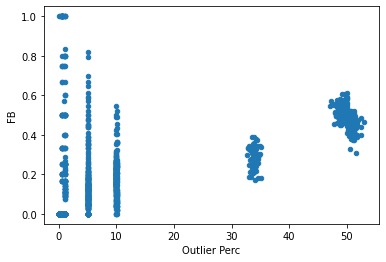

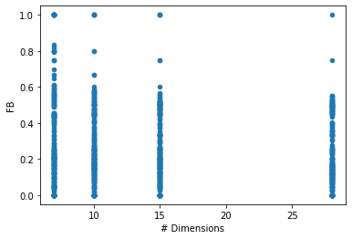

```python
prn_df.plot.scatter(x='Outlier Perc', y='FB')
prn_df.plot.scatter(x='# Dimensions', y='FB')
```

### 从上图可以看出，FB的结果和异常值比例关联较大，和特征维度关系不是非常明显。基本来说，异常值的增多会使得FB算法的精确度提高。

## 3、结果可视化

### 这一节，我们选择一个benchmark对八种离群点检测算法进行结果可视化。由于特征维度大于2，我们必须使用降维策略。后续使用了两种降维策略，分别是TSNE和PCA，我们可以直观感受下哪种策略可视化效果好。

### (1) TSNE降维

```
... Processing abalone_benchmark_0001.csv ...
0.4835805084745763
Feature Bagging ROC:0.585, precision @ rank n:0.5633, execution time: 0.0096s
```

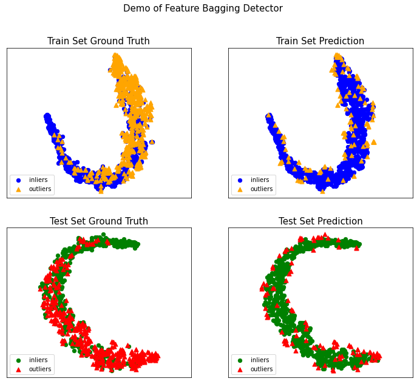

```
Histogram-base Outlier Detection (HBOS) ROC:0.478, precision @ rank n:0.459, execution time: 0.0096s
```

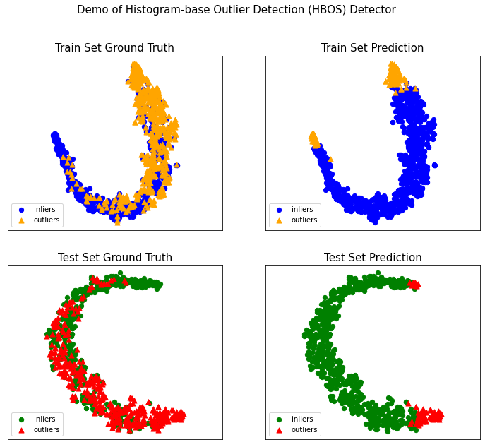

```
Isolation Forest ROC:0.4955, precision @ rank n:0.4717, execution time: 0.0096s
```

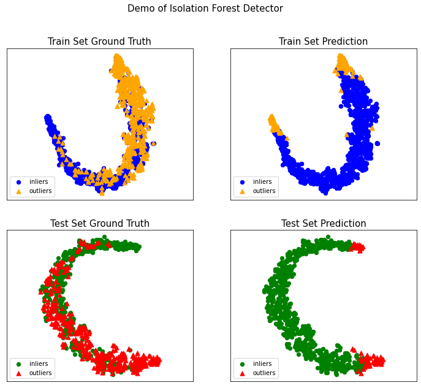

```
K Nearest Neighbors (KNN) ROC:0.7576, precision @ rank n:0.6765, execution time: 0.0096s
```

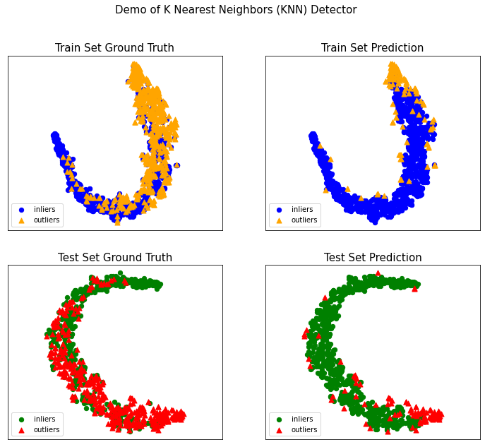

```
Local Outlier Factor (LOF) ROC:0.5822, precision @ rank n:0.566, execution time: 0.0096s
```

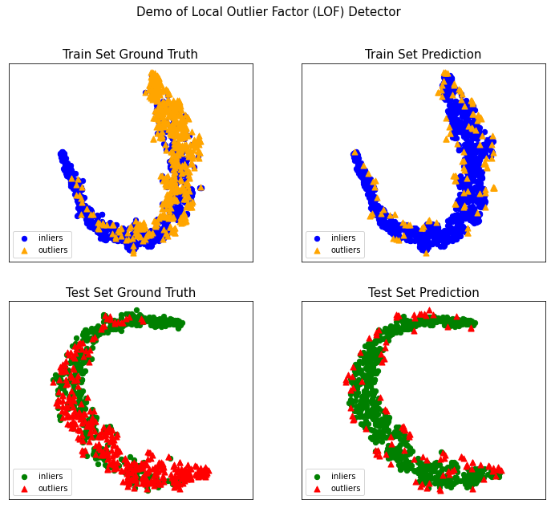

```
Minimum Covariance Determinant (MCD) ROC:0.757, precision @ rank n:0.6927, execution time: 0.0096s
```

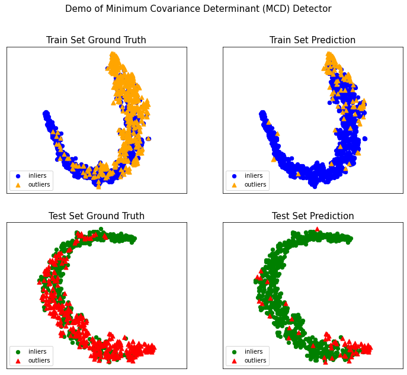

```
One-class SVM (OCSVM) ROC:0.5082, precision @ rank n:0.504, execution time: 0.0096s
```

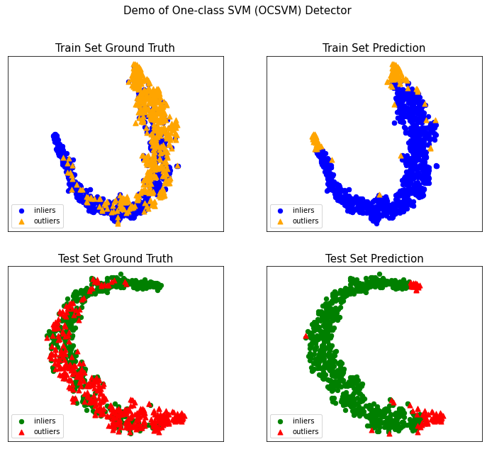

```
Principal Component Analysis (PCA) ROC:0.5049, precision @ rank n:0.4879, execution time: 0.0096s
```

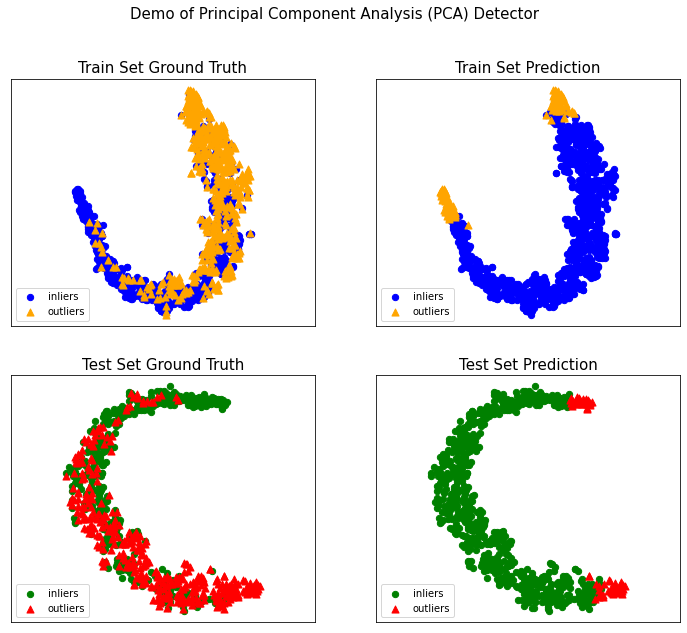

```python
print("\n... Processing", 'abalone_benchmark_0001.csv', '...')
file = pd.read_csv(os.path.join(dir_path, 'abalone_benchmark_0001.csv'))

X = file.values[:, 6:]
y = (file.values[:, 5] == 'anomaly')+0
outliers_fraction = np.count_nonzero(y) / len(y)
outliers_percentage = round(outliers_fraction * 100, ndigits=4)
print(outliers_fraction)


if outliers_fraction > 0.5:
    outliers_fraction = 1 - outliers_fraction
    y = 1 - y

# 60% 训练集， 40% 测试集
X_train, X_test, y_train, y_test = train_test_split(X, y, test_size=0.4,
                                                    random_state=random_state)
# 当测试集只含有一类时重新划分
while (len(np.unique(y_test)) != 2):
    X_train, X_test, y_train, y_test = train_test_split(X, y, test_size=0.4,
                                                        random_state=random_state)

# 数据已经经过了标准化，直接传入就行
X_train_norm, X_test_norm = X_train, X_test

X_train_tsne = TSNE(n_components=2)
X_train_tsne.fit_transform(X_train)
X_test_tsne = TSNE(n_components=2)
X_test_tsne.fit_transform(X_test)

for clf_name, clf in classifiers.items():
    clf.fit(X_train_norm)
    test_scores = clf.decision_function(X_test_norm)
    y_train_pred = clf.labels_  # binary labels (0: inliers, 1: outliers)
    y_test_pred = clf.predict(X_test)  # outlier labels (0 or 1)

    roc = round(roc_auc_score(y_test, test_scores), ndigits=4)
    prn = round(precision_n_scores(y_test, test_scores), ndigits=4)

    print('{clf_name} ROC:{roc}, precision @ rank n:{prn}, '
          'execution time: {duration}s'.format(
        clf_name=clf_name, roc=roc, prn=prn, duration=duration))
    visualize(clf_name, X_train_tsne.embedding_, y_train, X_test_tsne.embedding_, y_test, y_train_pred, y_test_pred, show_figure=True, save_figure=False)
```

### (2) PCA降维

```
Feature Bagging ROC:0.584, precision @ rank n:0.5606, execution time: 0.0096s
```

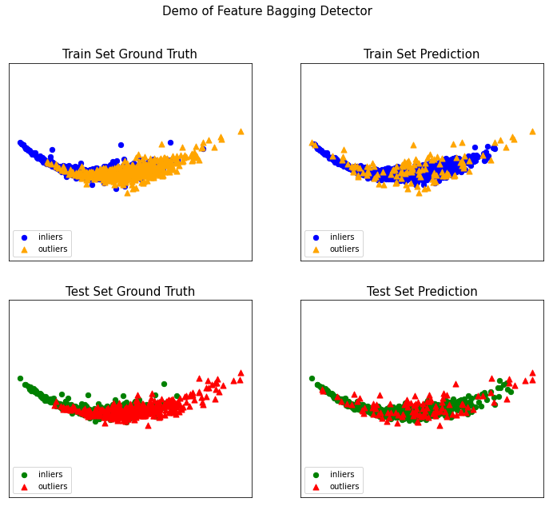

```
Histogram-base Outlier Detection (HBOS) ROC:0.478, precision @ rank n:0.459, execution time: 0.0096s
```

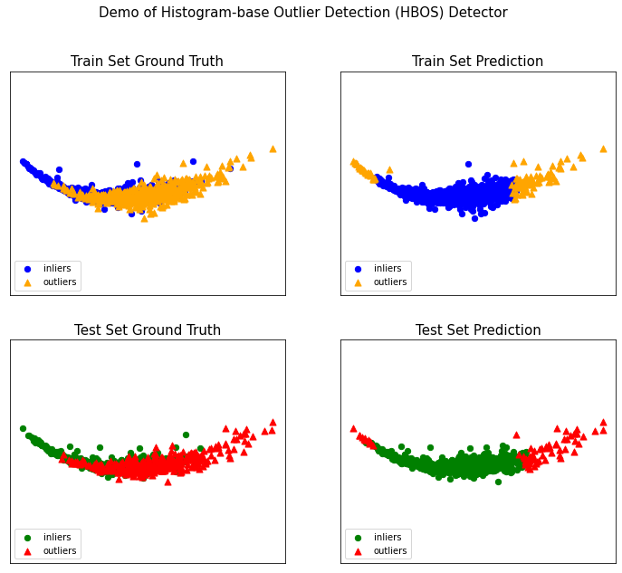

```
Isolation Forest ROC:0.4745, precision @ rank n:0.4609, execution time: 0.0096s
```

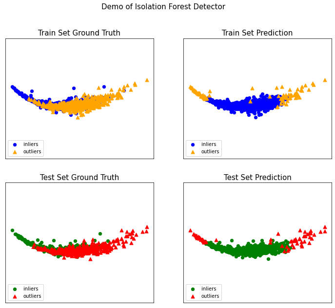

```
K Nearest Neighbors (KNN) ROC:0.7576, precision @ rank n:0.6765, execution time: 0.0096s
```

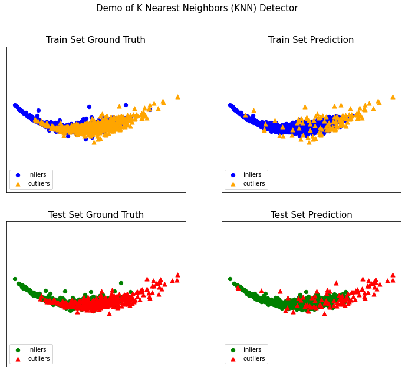

```
Local Outlier Factor (LOF) ROC:0.5822, precision @ rank n:0.566, execution time: 0.0096s
```

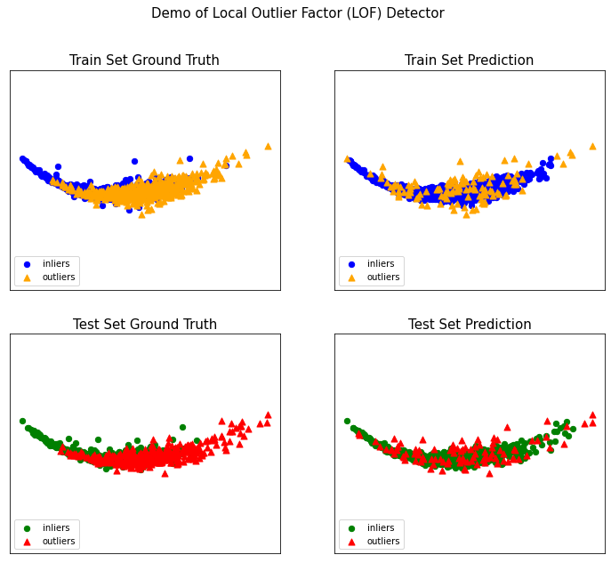

```
Minimum Covariance Determinant (MCD) ROC:0.757, precision @ rank n:0.6927, execution time: 0.0096s
```

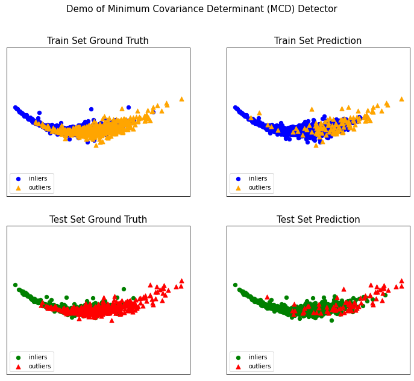

```
One-class SVM (OCSVM) ROC:0.5082, precision @ rank n:0.504, execution time: 0.0096s
```

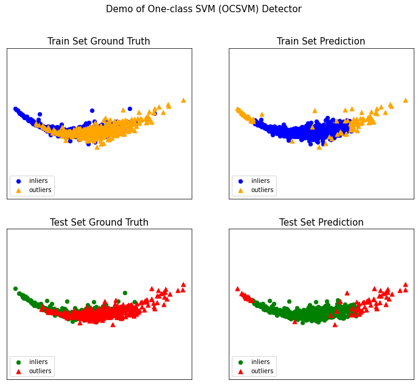

```
Principal Component Analysis (PCA) ROC:0.5049, precision @ rank n:0.4879, execution time: 0.0096s
```

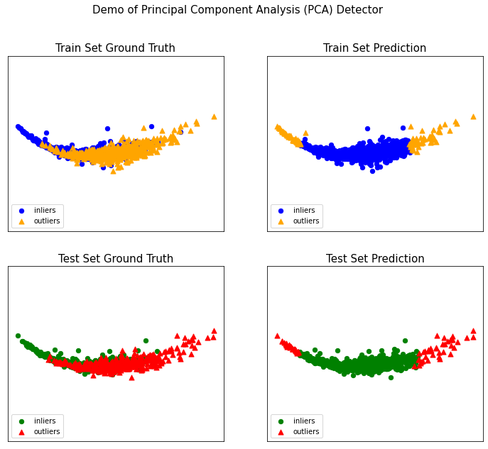

```python
pca = PCA_d(n_components=2)                        #加载PCA算法，设置降维后主成分数为2
X_train_PCA = pca.fit_transform(X_train)
pca_test = PCA_d(n_components=2)
X_test_PCA = pca_test.fit_transform(X_test)
for clf_name, clf in classifiers.items():
    clf.fit(X_train_norm)
    test_scores = clf.decision_function(X_test_norm)
    y_train_pred = clf.labels_  # binary labels (0: inliers, 1: outliers)
    y_test_pred = clf.predict(X_test)  # outlier labels (0 or 1)

    roc = round(roc_auc_score(y_test, test_scores), ndigits=4)
    prn = round(precision_n_scores(y_test, test_scores), ndigits=4)

    print('{clf_name} ROC:{roc}, precision @ rank n:{prn}, '
          'execution time: {duration}s'.format(
        clf_name=clf_name, roc=roc, prn=prn, duration=duration))
    visualize(clf_name, X_train_PCA, y_train, X_test_PCA, y_test, y_train_pred, y_test_pred, show_figure=True, save_figure=False)
```

## 以上就是我使用八种离群点分析算法对该数据集进行处理的过程。